# Casual Inference Notebook

# Open part

Instead of the glm to calculate the propensity score use any machine learning technique you like such as a regression tree (using rpart), or random forests (randomForest) in R to create the propensity score model and to predict the probabilities on such a model. Note that you might need to tweak the model parameters in order to improve it. Compare your results to those you obtained by matching (via the Mahalanobis distance and the propensity score with logistic regression). Which approach do you prefer and why?

```r
#1. Propensity score using a different machine learning technique like Random Forest.

# install.packages('randomForest')      #install package if need it
library(randomForest)

rhc.rf <- rhc.selected        #copying df to work on this
rhc.rf$treatment.swang <- as.factor(rhc.rf$treatment.swang)
rfFormula <- reformulate(xvars, response = "treatment.swang")
RFmodel <- randomForest(formula = rfFormula, data=rhc.rf, ntree=500, max_depth=1000)
forestScores <- predict(RFmodel, type="prob")
#summary(RFmodel)                   #if needed uncomment it
```

```r
pscoreRF <- data.frame(forestScores[,2])
comparisonDF <- data.frame("RandomForest"= forestScores[,2], "Treatment" = rhc.selected$treatment.swang)
```

```r
#Plotting the propensity scores for the two groups to check the overlap

gotTreatment2 <- comparisonDF$RandomForest[comparisonDF$Treatment==1]
gotNoTreatment2 <- comparisonDF$RandomForest[comparisonDF$Treatment==0]
# par(mfrow=c(2,1))
# hist(gotTreatment2, main='Group with treatment', xlab ='Propensity Score', ylim=c(0,650), col='darkblue')
# hist(gotNoTreatment2, main='Group without treatment', xlab ='Propensity Score', ylim=c(650,0), col='red')


#density hist
par(mfrow=c(2,1))
hist(gotTreatment2, main='Treatment group', xlab='Propensity Score', xlim=c(0,1), ylim=c(0,3), col='darkblue',
     prob = TRUE)   #shows density instead of frequency
lines(density(gotTreatment2),
      lwd = 2,
      col = "orange")
```

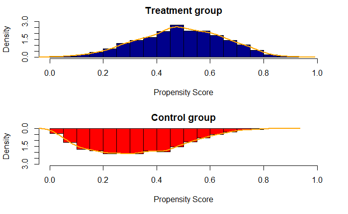

```r
hist(gotNoTreatment2, main='Control group', xlab='Propensity Score', xlim=c(0,1),ylim=c(3,0), col='red',
     prob = TRUE)   #shows density instead of frequency
lines(density(gotNoTreatment2),
      lwd = 2,
      col = "orange")
```

```r
logitTreatment2 <- logit(gotTreatment2)
logitNoTreatment2 <- logit(gotNoTreatment2)

#density hist
par(mfrow=c(2,1))
hist(logitTreatment2, main='Treatment group', xlab='Log-odds of Propensity Score', xlim=c(-4,4), ylim=c(0,0.6), col='darkblue',
     prob = TRUE)   #shows density instead of frequency
lines(density(logitTreatment2),
      lwd = 2,
      col = "orange")
```

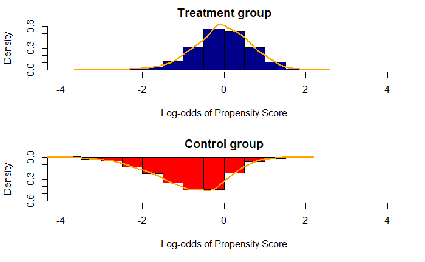

```r
hist(logitNoTreatment2, main='Control group', xlab='Log-odds of Propensity Score', xlim=c(-4,4),ylim=c(0.6,0), col='red',
     prob = TRUE)   #shows density instead of frequency
lines(density(logitNoTreatment2),
      lwd = 2,
      col = "orange")
```

```r
pscoreRF_v <- c(pscoreRF[,1])   #creating a vector of the PS
```

```r
#matching PS
psmatch2 <- Match(Tr=rhc.selected$treatment.swang, M=1, X=logit(pscoreRF_v), replace=FALSE, caliper = .2)
matched2 <- rhc.selected[unlist(psmatch2[c("index.treated","index.control")]), ]
```

```r
matchedtab2 <- CreateTableOne(vars=xvars, strata = "treatment.swang",
                            data=matched2, test = FALSE)
# Printing the matching table to show the SMD
print(matchedtab2, smd = TRUE)
```

```
                             Stratified by treatment.swang
                              0             1             SMD
  n                            1678          1678
  ARF (mean (SD))              0.45 (0.50)   0.43 (0.50)   0.036
  CHF (mean (SD))              0.09 (0.28)   0.10 (0.30)   0.039
  Cirrhosis (mean (SD))        0.04 (0.19)   0.02 (0.15)   0.069
  Coma (mean (SD))             0.06 (0.23)   0.05 (0.21)   0.046
  Lung_Cancer (mean (SD))      0.01 (0.09)   0.00 (0.04)   0.098
  MOSF_Malignancy (mean (SD))  0.09 (0.28)   0.08 (0.26)   0.044
  cardiohx (mean (SD))         0.19 (0.39)   0.20 (0.40)   0.027
  chfhx (mean (SD))            0.19 (0.39)   0.19 (0.39)   0.011
  dementhx (mean (SD))         0.10 (0.30)   0.07 (0.26)   0.107
  psychhx (mean (SD))          0.07 (0.25)   0.05 (0.22)   0.069
  chrpulhx (mean (SD))         0.15 (0.36)   0.16 (0.36)   0.013
  renalhx (mean (SD))          0.06 (0.24)   0.05 (0.22)   0.052
  liverhx (mean (SD))          0.07 (0.25)   0.06 (0.24)   0.039
  malighx (mean (SD))          0.26 (0.44)   0.21 (0.41)   0.118
  immunhx (mean (SD))          0.30 (0.46)   0.29 (0.45)   0.033
  transhx (mean (SD))          0.10 (0.30)   0.13 (0.34)   0.103
  age (mean (SD))             61.18 (16.90) 61.11 (16.06)  0.005
  edu (mean (SD))             11.60 (3.12)  11.74 (3.15)   0.047
  das2d3pc (mean (SD))        20.57 (5.32)  20.58 (5.08)   0.002
  aps1 (mean (SD))            58.57 (19.40) 57.89 (19.55)  0.035
  scoma1 (mean (SD))          19.65 (29.33) 19.23 (28.41)  0.014
  meanbp1 (mean (SD))         73.31 (35.58) 72.91 (36.10)  0.011
  wblc1 (mean (SD))           16.10 (13.17) 15.91 (12.44)  0.015
  temp1 (mean (SD))           37.65 (1.85)  37.59 (1.81)   0.036
  alb1 (mean (SD))             3.01 (0.70)   3.01 (0.96)   0.005
  hema1 (mean (SD))           30.61 (8.01)  30.71 (7.63)   0.014
  bili1 (mean (SD))            2.64 (5.66)   2.45 (4.93)   0.037
  crea1 (mean (SD))            2.43 (2.35)   2.29 (2.01)   0.068
  pot1 (mean (SD))             4.14 (1.13)   4.01 (0.99)   0.117
  paco21 (mean (SD))          37.42 (12.19) 37.29 (11.36)  0.011
  ph1 (mean (SD))              7.39 (0.11)   7.39 (0.11)   0.004
  wtkilo1 (mean (SD))         69.96 (26.70) 69.84 (27.58)  0.004
  dnr1 (mean (SD))             0.11 (0.32)   0.08 (0.27)   0.111
  resp (mean (SD))             0.33 (0.47)   0.33 (0.47)   0.001
  card (mean (SD))             0.37 (0.48)   0.39 (0.49)   0.039
  gastr (mean (SD))            0.18 (0.38)   0.19 (0.39)   0.029
  renal (mean (SD))            0.06 (0.23)   0.06 (0.24)   0.020
  hema (mean (SD))             0.08 (0.27)   0.06 (0.23)   0.099
  seps (mean (SD))             0.21 (0.41)   0.22 (0.41)   0.017
  trauma (mean (SD))           0.01 (0.08)   0.01 (0.12)   0.076
```

```r
# Looking for bad balance
addmargins(table(ExtractSmd(matchedtab2) > 0.2))
```

```
FALSE   Sum
   40    40
```

```r
print('There are no variables with bad balance (SMD>0.2).')
```

```
[1] "There are no variables with bad balance (SMD>0.2)."
```

```r
#2. Compare the results to those previously obtained by matching (via the Mahalanobis distance and the propensity score with logistic regression).
```

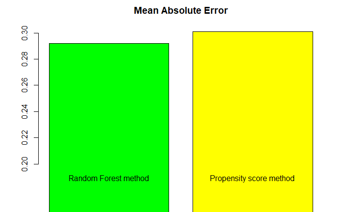

```r
#calculating mean absolute error between two models

pscoreRF_v <- c(pscoreRF[,1])      ## creating a vector of the PS
predictedRF <- round(pscoreRF_v)   ## predicted values of random forest, propensity score
predictedPS <- round(prs_df$pr_score)
observed <- as.numeric(rhc$swang1=='RHC')
maeRF <- mae(predictedRF, observed)
maePS <- mae(predictedPS, observed)
barplot(c(maeRF, maePS), main="Mean Absolute Error",
   ylim=c(0.2,0.31), names=c('Random Forest method', 'Propensity score method'), col=c('green', 'yellow'))
```

```r
smd_dataPlot <- data.frame(variable   = rownames(ExtractSmd(matchedtab1)),
                       LR  = as.numeric(ExtractSmd(matchedtab1)),
                       RF    = as.numeric(ExtractSmd(matchedtab2)))
print(smd_dataPlot)
```

| variable | LR | RF |
| --- | --- | --- |
| ARF | 0.033674726 | 0.036035314 |
| CHF | 0.011516896 | 0.039388313 |
| Cirrhosis | 0.010823674 | 0.069451805 |
| Coma | 0.000000000 | 0.045816519 |
| Lung_Cancer | 0.010256283 | 0.097999402 |
| MOSF_Malignancy | 0.004261728 | 0.043525305 |
| cardiohx | 0.014369471 | 0.026951610 |
| chfhx | 0.001448635 | 0.010634827 |
| dementhx | 0.006581561 | 0.107133507 |
| psychhx | 0.005172480 | 0.068800521 |

[output cut: 30 more lines]

```r
print("When comparing the methods (PS method and RF), we can see from Mean Absolute error graph that we get a slightly lower value for Random Forest method. Additionally, when comparing their histograms of propensity score, we noticed a general good overlap with higher density for LR method and, on the other hand, less overlap for high propensity scores when using RF method. Finally, when checking the SMD table from both LR and RF, we noticed that LR has lower SMD so less risk to have 'bad' balance.")
```

[output not shown]

```r
#3. Which approach do you prefer and why?

print("Although we got better MAE on random forest, we prefer the approach that uses logistic regression for different reasons:
      1. We got slightly better results;
      2. It seems easier to implement;
      3. It is more popular therefore more documentation and explanation can be found.")
```

```
[1] "Although we got better MAE on random forest, we prefer the approach that uses logistic regression for different reasons:\n      1. We got slightly better results;\n      2. It seems easier to implement; \n      3. It is more popular therefore more documentation and explanation can be found."
```